# Reproducible Research: Peer Assessment 1

## Loading and preprocessing the data

First we read the data and take a look at it:

```r
RawData<-read.csv("activity.csv")
summary(RawData)
```

```
##      steps                date          interval
##  Min.   :  0.00   2012-10-01:  288   Min.   :   0.0
##  1st Qu.:  0.00   2012-10-02:  288   1st Qu.: 588.8
##  Median :  0.00   2012-10-03:  288   Median :1177.5
##  Mean   : 37.38   2012-10-04:  288   Mean   :1177.5
##  3rd Qu.: 12.00   2012-10-05:  288   3rd Qu.:1766.2
##  Max.   :806.00   2012-10-06:  288   Max.   :2355.0
##  NA's   :2304     (Other)   :15840
```

## What is mean total number of steps taken per day?

For further we need some packages:

```r
library(ggplot2)
library(dplyr)
```

We group our Data by dates and summarize it. Now we can see mean and median values of number of steps per day:

```r
DataByDate <- group_by(RawData, date)
SumByDate <- summarise(DataByDate,
                       steps = sum(steps, na.rm = TRUE))
mean(SumByDate$steps, na.rm = TRUE)
```

```
## [1] 9354.23
```

```r
median(SumByDate$steps, na.rm = TRUE)
```

```
## [1] 10395
```

Now we are ready to print a histogram using ggplot2-package:

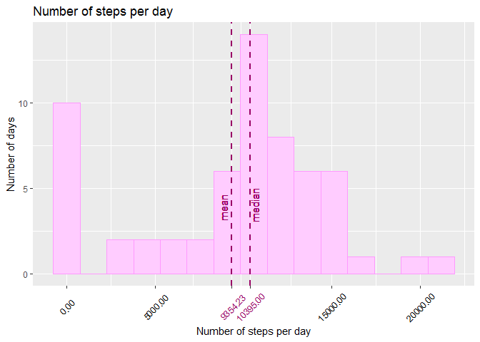

```r
c <- ggplot(SumByDate, aes(SumByDate$steps))
c <- c + geom_histogram(color = "#FF99FF",
                      fill = "#FFCCFF",
                      bins = 15)
c <- c + geom_vline(aes(xintercept = mean(SumByDate$steps)),
                  color = "#990066",
                  linetype ="dashed",
                  size = 1)
c <- c + geom_vline(aes(xintercept = median(SumByDate$steps)),
                  color = "#990066",
                  linetype ="dashed",
                  size = 1)
c <- c + geom_text(aes(x=mean(SumByDate$steps),
                       y=0,
                       label="mean"),
                   size=4,
                   angle=90,
                   vjust=-0.5,
                   hjust= -2,
                   color = "#990066")
c <- c + geom_text(aes(x=median(SumByDate$steps),
                       y=0,
                       label="median"),
                   size=4,
                   angle=90,
                   vjust= 1,
                   hjust= -1.5,
                   color = "#990066")
c <- c + labs(title = "Number of steps per day",
              y = "Number of days",
              x = "Number of steps per day"
           )
c <- c + scale_x_continuous(breaks = c(0,
                                       5000,
                                       mean(SumByDate$steps),
                                       median(SumByDate$steps),
                                       15000,
                                       20000)
                            )
c <- c + theme(axis.text.x = element_text(color = c("black",
                                                    "black",
                                                    "#990066",
                                                    "#990066",
                                                    "black",
                                                    "black"),
                                          angle = 45,
                                          vjust = 0.5
                                          )
               )

plot(c)
```

## What is the average daily activity pattern?

We group our data by interval and summarise to find some patterns across all days:

```r
DataByInterval <- group_by(RawData, interval)
AvgByInterval <- summarise(DataByInterval, steps = mean(steps, na.rm = TRUE))
```

Now we can look at maximum average number of steps per interval:

```r
MaxSteps <- max(AvgByInterval$steps)
MaxSteps
```

```
## [1] 206.1698
```

And the interval itself:

```r
MaxStepsInt <- AvgByInterval[which(AvgByInterval$steps == MaxSteps), "interval"]
MaxStepsInt
```

```
## # A tibble: 1 x 1
##   interval
##      <int>
## 1      835
```

Now we are ready to display this information as a time series plot of the 5-minute interval (x-axis) and the average number of steps taken, averaged across all days (y-axis).

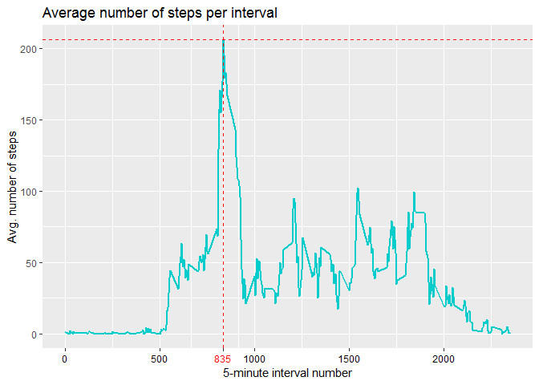

```r
MaxStepsInt <- as.numeric(MaxStepsInt)
c <- ggplot(AvgByInterval, aes(x = interval, y = steps))
c <- c + geom_line(size = 1, color = "#00CCCC")
c <- c + geom_hline(aes(yintercept = MaxSteps),
                    color = "red",
                    linetype = "dashed"
                    )
c <- c + geom_vline(aes(xintercept = MaxStepsInt),
                    color = "red",
                    linetype = "dashed")
c <- c + labs(title = "Average number of steps per interval",
              y = "Avg. number of steps",
              x = "5-minute interval number"
           )
c <- c + scale_x_continuous(breaks = c(0,
                                       500,
                                       MaxStepsInt,
                                       1000,
                                       1500,
                                       2000)
                            )
c <- c + theme(axis.text.x = element_text(color = c("black",
                                                    "black",
                                                    "red",
                                                    "black",
                                                    "black",
                                                    "black")
                                          )
               )

plot(c)
```

## Imputing missing values

First let’s take a look on amount of NA’s in our data:

```r
sum(is.na(RawData$steps))
```

```
## [1] 2304
```

Now we will form a new dataset with filled in NA’s by the average number of steps across all days for this interval:

```r
FullData <- RawData
FullData <- left_join(FullData, AvgByInterval, by = "interval")
FullData$steps.x[is.na(FullData$steps.x)] <- FullData$steps.y[is.na(FullData$steps.x)]
summary(FullData)
```

```
##     steps.x               date          interval         steps.y
##  Min.   :  0.00   2012-10-01:  288   Min.   :   0.0   Min.   :  0.000
##  1st Qu.:  0.00   2012-10-02:  288   1st Qu.: 588.8   1st Qu.:  2.486
##  Median :  0.00   2012-10-03:  288   Median :1177.5   Median : 34.113
##  Mean   : 37.38   2012-10-04:  288   Mean   :1177.5   Mean   : 37.383
##  3rd Qu.: 27.00   2012-10-05:  288   3rd Qu.:1766.2   3rd Qu.: 52.835
##  Max.   :806.00   2012-10-06:  288   Max.   :2355.0   Max.   :206.170
##                   (Other)   :15840
```

Now we can see, that there are no NA’s in steps-column any more.

Let’s see how mean and median estimates of total number of steps taken per day changed after imputing missing values:

```r
FDataByDate <- group_by(FullData, date)
FSumByDate <- summarise(FDataByDate,
                       steps = sum(steps.x))
mean(FSumByDate$steps)
```

```
## [1] 10766.19
```

```r
median(FSumByDate$steps)
```

```
## [1] 10766.19
```

We can see, that the estimates increased (and somehow became equal).

Now let’s look on hystogram:

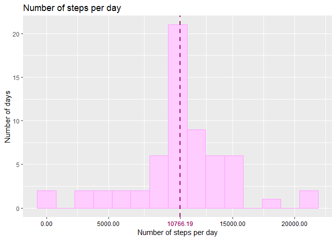

```r
c <- ggplot(FSumByDate, aes(FSumByDate$steps))
c <- c + geom_histogram(color = "#FF99FF",
                      fill = "#FFCCFF",
                      bins = 15)
c <- c + geom_vline(aes(xintercept = mean(FSumByDate$steps)),
                  color = "#990066",
                  linetype ="dashed",
                  size = 1)
c <- c + geom_vline(aes(xintercept = median(FSumByDate$steps)),
                  color = "#990066",
                  linetype ="dashed",
                  size = 1)
c <- c + labs(title = "Number of steps per day",
              y = "Number of days",
              x = "Number of steps per day"
           )
c <- c + scale_x_continuous(breaks = c(0, 5000, mean(FSumByDate$steps), median(FSumByDate$steps), 15000, 20000))
c <- c + theme(axis.text.x = element_text(color = c("black",
                                                    "black",
                                                    "#990066",
                                                    "#990066",
                                                    "black",
                                                    "black")
                                          )
               )

plot(c)
```

## Are there differences in activity patterns between weekdays and weekends?

Now we are going to look at activity patterns on weekdays and weekends. First we need to flag our data:

```r
FullData$wday <- factor(case_when(weekdays(as.Date(FullData$date)) %in% c("Sunday", "Saturday") ~ "weekend",
                                  TRUE ~ "weekday"
                                  )
                        )
summary(FullData)
```

```
##     steps.x               date          interval         steps.y
##  Min.   :  0.00   2012-10-01:  288   Min.   :   0.0   Min.   :  0.000
##  1st Qu.:  0.00   2012-10-02:  288   1st Qu.: 588.8   1st Qu.:  2.486
##  Median :  0.00   2012-10-03:  288   Median :1177.5   Median : 34.113
##  Mean   : 37.38   2012-10-04:  288   Mean   :1177.5   Mean   : 37.383
##  3rd Qu.: 27.00   2012-10-05:  288   3rd Qu.:1766.2   3rd Qu.: 52.835
##  Max.   :806.00   2012-10-06:  288   Max.   :2355.0   Max.   :206.170
##                   (Other)   :15840
##       wday
##  weekday:12960
##  weekend: 4608
##
##
##
##
##
```

Now we can group our data by wday-flag and interval:

```r
FDataByIntWday <- group_by(FullData, interval, wday)
FAvgByIntWday <- summarise(FDataByIntWday, steps = mean(steps.x))
```

Now we are ready to print a plot with two patterns - for weekdays and for weekends:

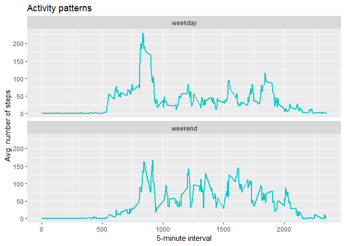

```r
c <- ggplot(FAvgByIntWday, aes(x = interval, y = steps))
c <- c + geom_line(size = 1, color = "#00CCCC")
c <- c + facet_wrap(vars(wday), ncol = 1, nrow = 2)
c <- c + labs(title = "Activity patterns",
              y = "Avg. number of steps",
              x = "5-minute interval"
           )
plot(c)
```

We can see, that in general there are more active intervals on weekends, though maximum number of steps per interval is reached on a weekday. Also we can see that activity starts later in the morning on weekends.